# Analyze Cancer Diagnoses By Stage with Python

## Introduction: Late Diagnosis of Cancer Decreases Chance of Patient Survival

- According to the National Cancer Institute, cancers of the lung and bronchus, colon and rectum, pancreas, and breast are estimated to cause the most cancer deaths in the year 2019 (1).
- Early diagnosis of cancer yields better health outcomes than late diagnosis.

## Objective: Identify Early and Late-Diagnosed Cancers

- I want to find which of the four deadliest cancers tend to be diagnosed early in the localized stage, and which ones are usually diagnosed later in the distant stage when the cancer has spread more throughout the body.
- My goal is to put data from these four cancers on a single chart so that the cancers are easy to compare.

## Import Pandas Library for Data Manipulation

```python
import pandas as pd
```

## Import Pyplot Module from Matplotlib Library to Create Charts

```python
from matplotlib import pyplot as plt
```

## Load Data from CSV Files into Variables

- I used CSV files from The National Cancer Institute SEER*Explorer website (2).

```python
colonRectumCancerData = pd.read_csv('colonRectumCancerStages.csv')
```

```python
lungBronchusCancerData = pd.read_csv('lungBronchusCancerStages.csv')
```

```python
pancreaticCancerData = pd.read_csv('pancreaticCancerStages.csv')
```

```python
breastCancerData = pd.read_csv('breastCancerStages.csv')
```

### *Example: The colonRectumCancerData Data Frame Only Holds Information on Colon and Rectum Cancers*

```python
colonRectumCancerData.head()
```

|  | Sex | Race/Ethnicity | Age | Stage | AgeadjustedRateper100000 | Age-adjusted Rate Standard Error | Age-adjusted Rate Lower Confidence Interval | Age-adjusted Rate Upper Confidence Interval |
| --- | --- | --- | --- | --- | --- | --- | --- | --- |
| 1 | Both Sexes | All Races (includes Hispanic) | All Ages | Localized | 14.7455 | 0.0485 | 14.6506 | 14.8408 |
| 2 | Both Sexes | All Races (includes Hispanic) | All Ages | Regional | 13.3238 | 0.0462 | 13.2334 | 13.4148 |
| 3 | Both Sexes | All Races (includes Hispanic) | All Ages | Distant | 8.0771 | 0.0359 | 8.0069 | 8.1479 |
| 6 | Both Sexes | All Races (includes Hispanic) | Ages < 50 | Localized | 2.5825 | 0.0263 | 2.5313 | 2.6345 |
| 7 | Both Sexes | All Races (includes Hispanic) | Ages < 50 | Regional | 2.7861 | 0.0274 | 2.7326 | 2.8404 |

## Remove Rows with Values '-,' 'All Stages,' and 'Unstaged'

```python
colonRectumCancerData = colonRectumCancerData[(colonRectumCancerData.AgeadjustedRateper100000 != '-') & (colonRectumCancerData.Stage != 'All Stages') & (colonRectumCancerData.Stage != 'Unstaged')]
```

```python
lungBronchusCancerData = lungBronchusCancerData[(lungBronchusCancerData.AgeadjustedRateper100000 != '-') & (lungBronchusCancerData.Stage != 'All Stages') & (lungBronchusCancerData.Stage != 'Unstaged')]
```

```python
pancreaticCancerData = pancreaticCancerData[(pancreaticCancerData.AgeadjustedRateper100000 != '-') & (pancreaticCancerData.Stage != 'All Stages') & (pancreaticCancerData.Stage != 'Unstaged')]
```

```python
breastCancerData = breastCancerData[(breastCancerData.AgeadjustedRateper100000 != '-') & (breastCancerData.Stage != 'All Stages') & (breastCancerData.Stage != 'Unstaged')]
```

## Organize Cancer Diagnosis Data By Stage: Localized, Regional, and Distant

```python
colonRectumLocalized = colonRectumCancerData[colonRectumCancerData.Stage == 'Localized']
```

```python
colonRectumRegional = colonRectumCancerData[colonRectumCancerData.Stage == 'Regional']
```

```python
colonRectumDistant = colonRectumCancerData[colonRectumCancerData.Stage == 'Distant']
```

```python
lungBronchusLocalized = lungBronchusCancerData[lungBronchusCancerData.Stage == 'Localized']
```

```python
lungBronchusRegional = lungBronchusCancerData[lungBronchusCancerData.Stage == 'Regional']
```

```python
lungBronchusDistant = lungBronchusCancerData[lungBronchusCancerData.Stage == 'Distant']
```

```python
pancreaticLocalized = pancreaticCancerData[pancreaticCancerData.Stage == 'Localized']
```

```python
pancreaticRegional = pancreaticCancerData[pancreaticCancerData.Stage == 'Regional']
```

```python
pancreaticDistant = pancreaticCancerData[pancreaticCancerData.Stage == 'Distant']
```

```python
breastLocalized = breastCancerData[breastCancerData.Stage == 'Localized']
```

```python
breastRegional = breastCancerData[breastCancerData.Stage == 'Regional']
```

```python
breastDistant = breastCancerData[breastCancerData.Stage == 'Distant']
```

### *Example: The colonRectumLocalized Data Frame Has Details on Colon and Rectum Cancers Diagnosed at the Localized Stage*

```python
colonRectumLocalized.head()
```

|  | Sex | Race/Ethnicity | Age | Stage | AgeadjustedRateper100000 | Age-adjusted Rate Standard Error | Age-adjusted Rate Lower Confidence Interval | Age-adjusted Rate Upper Confidence Interval |
| --- | --- | --- | --- | --- | --- | --- | --- | --- |
| 1 | Both Sexes | All Races (includes Hispanic) | All Ages | Localized | 14.7455 | 0.0485 | 14.6506 | 14.8408 |
| 6 | Both Sexes | All Races (includes Hispanic) | Ages < 50 | Localized | 2.5825 | 0.0263 | 2.5313 | 2.6345 |
| 11 | Both Sexes | All Races (includes Hispanic) | Ages 50-64 | Localized | 28.0014 | 0.1578 | 27.693 | 28.3123 |
| 16 | Both Sexes | All Races (includes Hispanic) | Ages 65+ | Localized | 68.6583 | 0.2991 | 68.0733 | 69.2472 |
| 21 | Both Sexes | All Races (includes Hispanic) | Ages <15 | Localized | 0.1334 | 0.011 | 0.1128 | 0.1567 |

## Select the 'Age-adjusted Rate per 100,000' Column

- I removed spaces and punctuation from the names of columns I used to solve a syntax error.
- I used the to_numeric() pandas method to convert the rate values from strings to floats.

```python
colonRectumLocalizedRates = pd.to_numeric(colonRectumLocalized.AgeadjustedRateper100000)
```

```python
colonRectumRegionalRates = pd.to_numeric(colonRectumRegional.AgeadjustedRateper100000)
```

```python
colonRectumDistantRates = pd.to_numeric(colonRectumDistant.AgeadjustedRateper100000)
```

```python
lungBronchusLocalizedRates = pd.to_numeric(lungBronchusLocalized.AgeadjustedRateper100000)
```

```python
lungBronchusRegionalRates = pd.to_numeric(lungBronchusRegional.AgeadjustedRateper100000)
```

```python
lungBronchusDistantRates = pd.to_numeric(lungBronchusDistant.AgeadjustedRateper100000)
```

```python
pancreaticLocalizedRates = pd.to_numeric(pancreaticLocalized.AgeadjustedRateper100000)
```

```python
pancreaticRegionalRates = pd.to_numeric(pancreaticRegional.AgeadjustedRateper100000)
```

```python
pancreaticDistantRates = pd.to_numeric(pancreaticDistant.AgeadjustedRateper100000)
```

```python
breastLocalizedRates = pd.to_numeric(breastLocalized.AgeadjustedRateper100000)
```

```python
breastRegionalRates = pd.to_numeric(breastRegional.AgeadjustedRateper100000)
```

```python
breastDistantRates = pd.to_numeric(breastDistant.AgeadjustedRateper100000)
```

```python
colonRectumLocalizedMean = colonRectumLocalizedRates.mean()
```

### *Example: The colonRectumLocalizedRates Series Has Information on the Average Number of Colon or Rectum Cancer Diagnoses per 100,000 People at the Localized Stage for Various Population Segments*

```python
colonRectumLocalizedRates.head()
```

```
1     14.7455
6      2.5825
11    28.0014
16    68.6583
21     0.1334
Name: AgeadjustedRateper100000, dtype: float64
```

## Calculate Average Rates per 100,000 People Using the mean() Method

```python
colonRectumLocalizedMean
```

```
29.037822631578955
```

```python
colonRectumRegionalMean = colonRectumRegionalRates.mean()
```

```python
colonRectumRegionalMean
```

```
28.15675333333332
```

```python
colonRectumDistantMean = colonRectumDistantRates.mean()
```

```python
colonRectumDistantMean
```

```
18.44989520958084
```

```python
lungBronchusLocalizedMean = lungBronchusLocalizedRates.mean()
```

```python
lungBronchusLocalizedMean
```

```
25.70350462427746
```

```python
lungBronchusRegionalMean = lungBronchusRegionalRates.mean()
```

```python
lungBronchusRegionalMean
```

```
27.400456287425147
```

```python
lungBronchusDistantMean = lungBronchusDistantRates.mean()
```

```python
lungBronchusDistantMean
```

```
65.8136695121951
```

```python
pancreaticLocalizedMean = pancreaticLocalizedRates.mean()
```

```python
pancreaticLocalizedMean
```

```
3.4814796052631576
```

```python
pancreaticRegionalMean = pancreaticRegionalRates.mean()
```

```python
pancreaticRegionalMean
```

```
9.196729220779224
```

```python
pancreaticDistantMean = pancreaticDistantRates.mean()
```

```python
pancreaticDistantMean
```

```
15.862974074074081
```

```python
breastLocalizedMean = breastLocalizedRates.mean()
```

```python
breastLocalizedMean
```

```
81.68493265306122
```

```python
breastRegionalMean = breastRegionalRates.mean()
```

```python
breastRegionalMean
```

```
32.37839797979797
```

```python
breastDistantMean = breastDistantRates.mean()
```

```python
breastDistantMean
```

```
9.162250602409642
```

## Put Cancer Stage Names into a List to be Used as X-coordinates

```python
cancerStages = ["Localized", "Regional", "Distant"]
```

## Put the Mean Values into Lists to be Used as Corresponding Y-coordinates

```python
colonRectumRatesByStage = [29.037822631578955, 28.15675333333332, 18.44989520958084]
```

```python
lungBronchusRatesByStage = [25.70350462427746, 27.400456287425147, 65.8136695121951]
```

```python
pancreaticRatesByStage = [3.4814796052631576, 9.196729220779224, 15.862974074074081]
```

```python
breastRatesByStage = [81.68493265306122, 32.37839797979797, 9.162250602409642]
```

## Individually, the Line Graphs Look Like This:

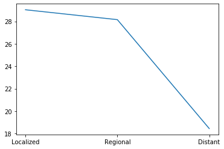

```python
plt.plot(cancerStages, colonRectumRatesByStage)
plt.show()
```

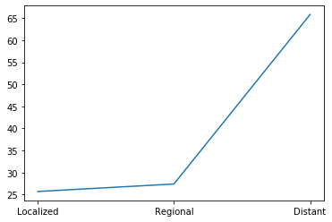

```python
plt.plot(cancerStages, lungBronchusRatesByStage)
plt.show()
```

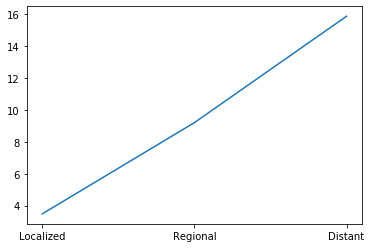

```python
plt.plot(cancerStages, pancreaticRatesByStage)
plt.show()
```

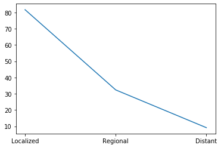

```python
plt.plot(cancerStages, breastRatesByStage)
plt.show()
```

## Plot Each of the Four Line Graphs on a Single Graph for Easier Comparison

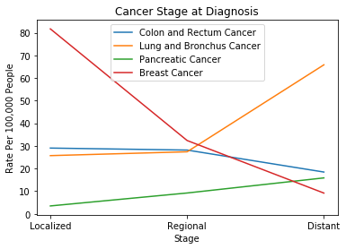

```python
plt.plot(cancerStages, colonRectumRatesByStage)
plt.plot(cancerStages, lungBronchusRatesByStage)
plt.plot(cancerStages, pancreaticRatesByStage)
plt.plot(cancerStages, breastRatesByStage)
plt.title("Cancer Stage at Diagnosis")
plt.xlabel("Stage")
plt.ylabel("Rate Per 100,000 People")
plt.legend(["Colon and Rectum Cancer", "Lung and Bronchus Cancer", "Pancreatic Cancer", "Breast Cancer"])
plt.show()
```

## Conclusion: Cancers are Not Diagnosed at the Same Stages

- Breast cancer and colon and rectum cancers are usually diagnosed early as seen by the downward slopes of their line graphs.
- Since their lines slope upwards, lung and bronchus cancer and pancreatic cancers tend to be diagnosed in the last stage.

## References

- 1. https://seer.cancer.gov/statfacts/html/common.html
- 1. https://seer.cancer.gov/explorer/